# Pierini Mignella Vestini HW1

2022-11-22

# Ex 1.

Initializations:

```r
# To save results (how much time) for each simulation size
times <- matrix(data = NA, nrow=2, ncol=6)
# True marginal PMF of T
pT <- function(t)  1/(t*(t+1))
# Sequence of time from 1 to 25 for the plots
t_seq =  1:25
```

Main function:

```r
sim <- function(M){
  # Get the M uniform samp
  X = lapply(M, function(x) runif(x))
  # Compute the geom on the X
  Y = lapply(X, function(X) rgeom(length(X), X))
  return (Y)
}
```

For M = {100, 1000, 10000, 100000, 1000000, 10000000} we are going to do the same simulation and check the results.

```r
# Simulation size
M = 100
# Save M
times[1,1] = M
# Initialize Y
Y = rep(NA, M)
# To compute how much time it takes
beg <- Sys.time()
# Find the geometric
Y = sim(times[1,1])
# And get the propotions
p_hat <- proportions(table(Y))
# Find and save how much time it takes
fin <- Sys.time() - beg
times[2,1] = fin
print(fin)
```

```
## Time difference of 0.002568007 secs
```

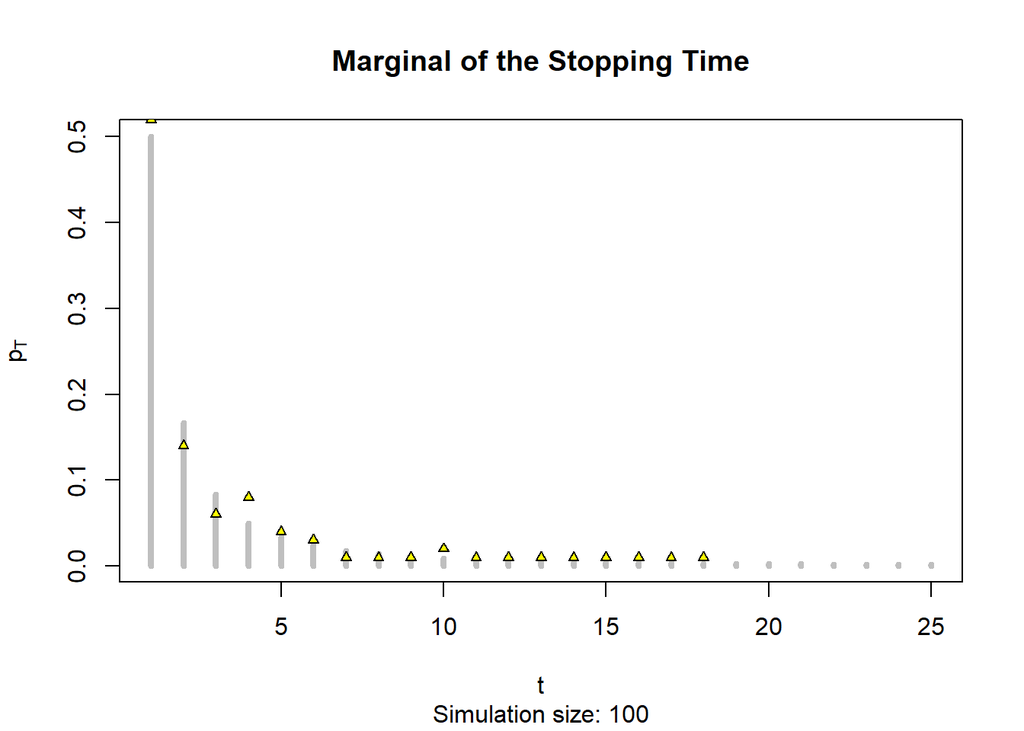

```r
# Plot of the True marginal PMF of T
plot(t_seq, pT(t_seq),
     type = "h",
     lwd = 4,
     col = rgb(0,0,0,.25),
     ylab = expression(p[T]),
     xlab = "t",
     main = "Marginal of the Stopping Time",
     sub = paste("Simulation size:", M))
# Simulative approximation to the PMF of T
points(t_seq, p_hat[t_seq], pch = 24,
       col = "black", bg = "yellow", cex = .7)
```

```r
M = 1000
times[1,2] = M
beg <- Sys.time()
Y=sim(times[1,2])
p_hat <- proportions(table(Y))
fin <- Sys.time() - beg
times[2,2] = fin
print(fin)
```

```
## Time difference of 0.01606703 secs
```

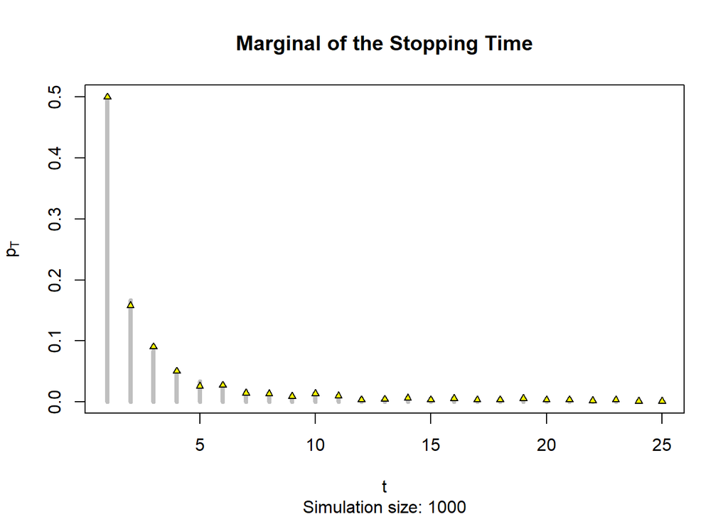

```r
plot(t_seq, pT(t_seq),
     type = "h",
     lwd = 4,
     col = rgb(0,0,0,.25),
     ylab = expression(p[T]),
     xlab = "t",
     main = "Marginal of the Stopping Time",
     sub = paste("Simulation size:", M))

# Simulative approximation to the PMF of T
points(t_seq, p_hat[t_seq], pch = 24,
       col = "black", bg = "yellow", cex = .7)
```

```r
M = 10000
times[1,3] = M
beg <- Sys.time()
Y <- sim(times[1,3])
p_hat <- proportions(table(Y))
fin <- Sys.time() - beg
times[2,3] = fin
print(fin)
```

```
## Time difference of 0.003829002 secs
```

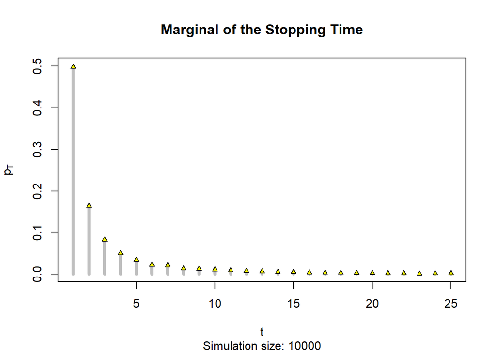

```r
plot(t_seq, pT(t_seq),
     type = "h",
     lwd = 4,
     col = rgb(0,0,0,.25),
     ylab = expression(p[T]),
     xlab = "t",
     main = "Marginal of the Stopping Time",
     sub = paste("Simulation size:", M))

# Simulative approximation to the PMF of T
points(t_seq, p_hat[t_seq], pch = 24,
       col = "black", bg = "yellow", cex = .7)
```

```r
M = 100000
times[1,4] = M
beg <- Sys.time()
Y <- sim(times[1,4])
p_hat <- proportions(table(Y))
fin <- Sys.time() - beg
times[2,4] = fin
print(fin)
```

```
## Time difference of 0.017205 secs
```

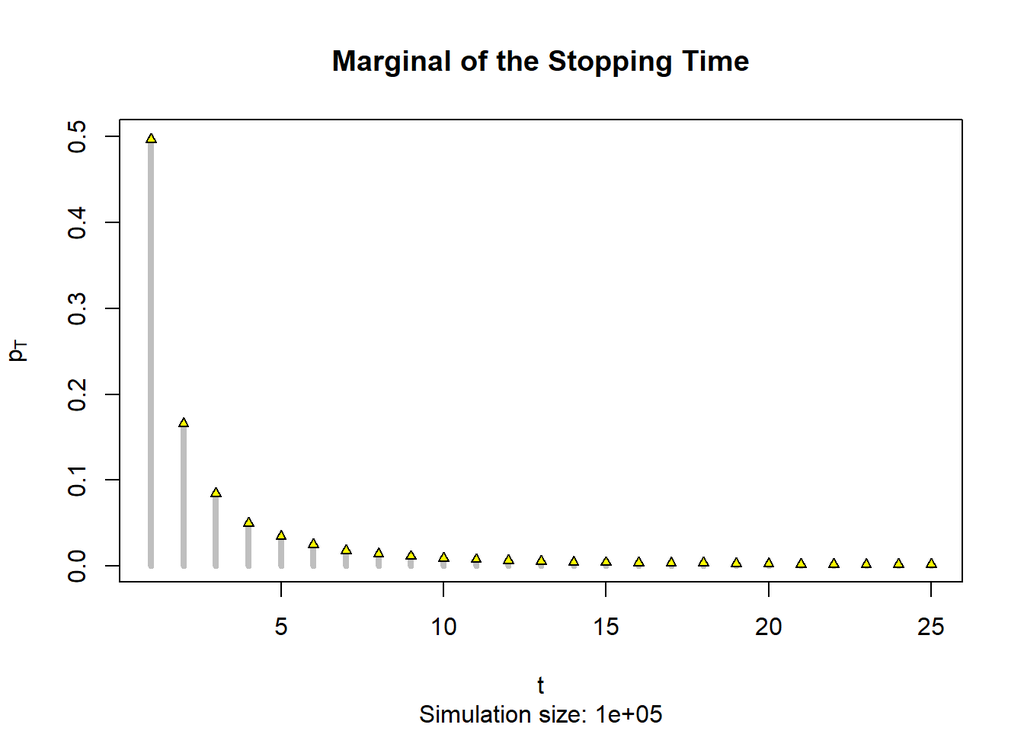

```r
plot(t_seq, pT(t_seq),
     type = "h",
     lwd = 4,
     col = rgb(0,0,0,.25),
     ylab = expression(p[T]),
     xlab = "t",
     main = "Marginal of the Stopping Time",
     sub = paste("Simulation size:", M))

# Simulative approximation to the PMF of T
points(t_seq, p_hat[t_seq], pch = 24,
       col = "black", bg = "yellow", cex = .7)
```

```r
M =  1000000
times[1,5] = M
beg <- Sys.time()
Y <- sim(times[1,5])
p_hat <- proportions(table(Y))
fin <- Sys.time() - beg
times[2,5] = fin
print(fin)
```

```
## Time difference of 0.1439109 secs
```

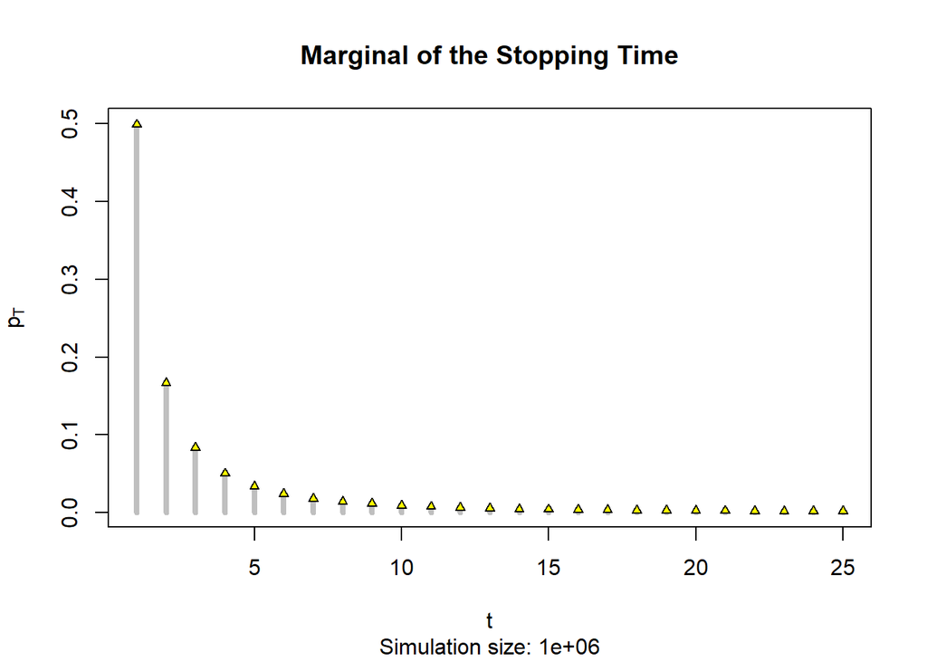

```r
plot(t_seq, pT(t_seq),
     type = "h",
     lwd = 4,
     col = rgb(0,0,0,.25),
     ylab = expression(p[T]),
     xlab = "t",
     main = "Marginal of the Stopping Time",
     sub = paste("Simulation size:", M))

# Simulative approximation to the PMF of T
points(t_seq, p_hat[t_seq], pch = 24,
       col = "black", bg = "yellow", cex = .7)
```

```r
M =  10000000
times[1,6] = M
beg <- Sys.time()
Y <- sim(times[1,6])
p_hat <- proportions(table(Y))
fin <- Sys.time() - beg
times[2,6] = fin
print(fin)
```

```
## Time difference of 1.532874 secs
```

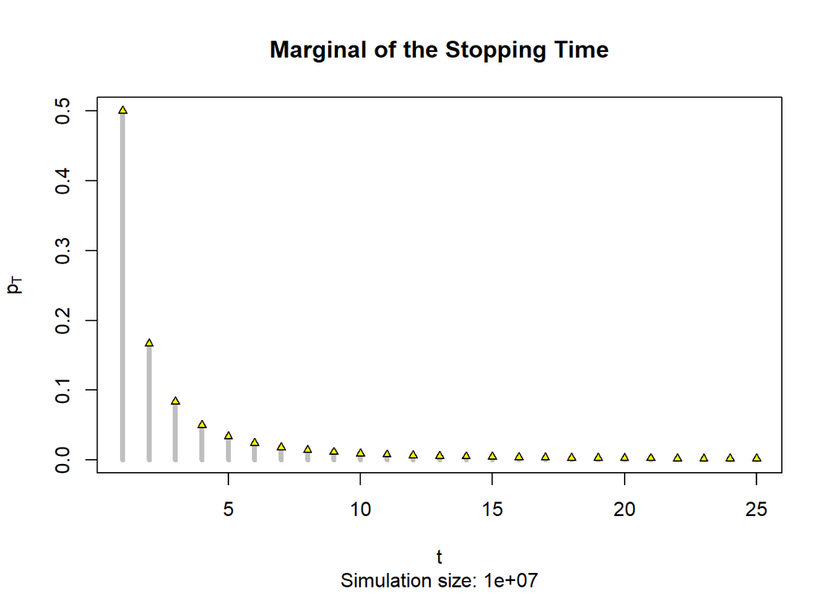

```r
plot(t_seq, pT(t_seq),
     type = "h",
     lwd = 4,
     col = rgb(0,0,0,.25),
     ylab = expression(p[T]),
     xlab = "t",
     main = "Marginal of the Stopping Time",
     sub = paste("Simulation size:", M))

# Simulative approximation to the PMF of T
points(t_seq, p_hat[t_seq], pch = 24,
       col = "black", bg = "yellow", cex = .7)
```

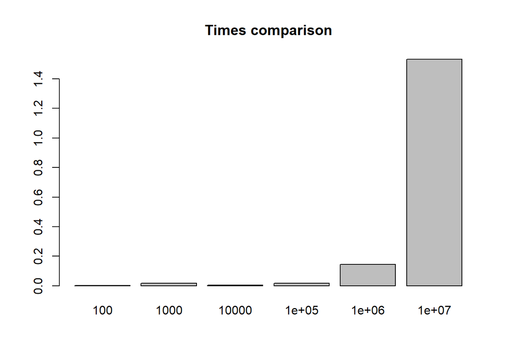

```r
# Let's take a look at how much time it took for each M
barplot(times[2,],names.arg = times[1,], main='Times comparison')
```

```r
print('And in general the mean of the time is: ')
```

```
## [1] "And in general the mean of the time is: "
```

```r
t <- mean(times[2,])
print(t)
```

```
## [1] 0.2860757
```

We can notice that with the simulation size getting bigger and bigger the results are more and more accurate.

# Ex 2.1 and 2.2

Initalization:

```r
greco <- 0.7
# simulation size
M <- 1000
integrals_p1 <- rep(NA,M)
integrals_q1 <- rep(NA,M)
integrals_p2 <- rep(NA,M)
integrals_q2 <- rep(NA,M)
compare_1 <- rep(NA,M)
compare_2 <- rep(NA,M)
```

Main function:

```r
sim <- function(m, n, e, M){
  # Initalization
  A <- rep(NA, 6)
  p_j = rep(0,m+2)
  q_j = rep(0,m+2)
  D_j = rep(NA,m)

  for(k in (1:M)){
    # 2.1

    # Sample from the beta(10, 10)
    X1 = rbeta(n,10,10)

    # Computing p_n,m:

    for (t in 2:m+1){
      # Compute p_j_hat
      p_j[t] = (sum(X1>((t-2)/m) & X1<=((t-1)/m))/n)
    }

    # Step function for the histogram p_n,m
    # Sequence of the extremes of the intervals that define the bins
    x <- seq(0,1, length.out = m+1)
    # Our p_n,m
    fun_p <- stepfun(x, p_j)

    # Compute the integral of the squared error of p_X (true density) and p_n,m
    integrals_p1[k] <- integrate(function(x) (dbeta(x,10,10)-(fun_p(x)*m))^2,
                                 0, 1, subdivisions = 2000)$value

    # Computing q_e,m:

    # Getting the sample for the Laplace distribution to privatize the data
    v = rlaplace(m, 0, sqrt(8/(e^2)))

    for (t in 1:m){
      # Compute D_j_tilde
      D_j[t] = max((p_j[t+1]*n)+v[t],0)
    }
    D = sum(D_j)

    for (t in 2:m+1){
      # Normalize the D_j_tilde in order to compute q_j_hat
      q_j[t] = D_j[t-1]/D
    }

    # Step function for the histogram q_e,m using the previous
    # extremes of the bins
    fun_q <- stepfun(x,q_j)

    # Compute the integral of the squared error of p_X (true density) and q_e,m
    integrals_q1[k] <- integrate(function(x) (dbeta(x,10,10)-(fun_q(x)*m))^2,
                                 0, 1, subdivisions = 2000)$value

    # Compute the integrals of the squared error
    # between the two histograms p_m,n and q_e,m
    compare_1[k] <- integrate(function(x) (fun_p(x)*m-fun_q(x)*m)^2,
                              0, 1, subdivisions = 2000)$value



    # 2.2

    # Sample from the mixture of beta(10,3) and beta(3,10) and to do that

    # We take the Bernoulli of probability p-greco
    samp <- rbernoulli(n, p = greco)
    # Then take as many samples from beta(10, 3)
    # as the True values from the Bernoulli
    x1 <- rbeta(sum(samp==T), 10, 3)
    # And beta(3, 10) as many as the False values
    x2 <- rbeta(sum(samp==F), 3, 10)
    # To finish it we concatenate them together
    X2 <- c(x1, x2)

    # Then we follow the same steps as the previous point

    for (t in 2:m+1){
      p_j[t] = (sum(X2>((t-2)/m) & X2<=((t-1)/m))/n)
    }

    x <- seq(0, 1, length.out = m+1)
    fun_p <- stepfun(x,p_j)

    integrals_p2[k] <- integrate(
      function(x) (greco*dbeta(x, 10, 3) + (1-greco)*dbeta(x, 3, 10)-(fun_p(x)*m))^2,
      0, 1, subdivisions = 2000)$value

    v = rlaplace(m, 0, sqrt(8/(e^2)))

    for (t in 1:m){
      D_j[t] = max((p_j[t+1]*n)+v[t],0)
    }
    D = sum(D_j)

    for (t in 2:m+1){

      q_j[t] = D_j[t-1]/D
    }

    fun_q <- stepfun(x,q_j)
    integrals_q2[k] <- integrate(
      function(x) (greco*dbeta(x, 10, 3) + (1-greco)*dbeta(x, 3, 10)-(fun_q(x)*m))^2,
      0, 1, subdivisions = 2000)$value

    compare_2[k] <- integrate(function(x) (fun_p(x)*m-fun_q(x)*m)^2,
                              0, 1, subdivisions = 2000)$value

  }
  # Save the mean value of each integral
  A[1] = mean(compare_1)
  A[2] = mean(integrals_p1)
  A[3] = mean(integrals_q1)

  A[4] = mean(compare_2)
  A[5] = mean(integrals_p2)
  A[6] = mean(integrals_q2)

  # And return the results
  return(A)
}
```

Now we are going to call the function with n = {100, 1000}, e = {0.1, 0.01}, and m = grid([5,50])

```r
e <- 0.1
n <- 100
Mise <- rep(NA, 6)
for(i in 5:50){
  Mise[i-4] = lapply(i, function(x) sim(x, n=n, e=e, M=M))
}
# Save the results in a 6 by 46 matrix
Mise <- matrix(unlist(Mise), nrow= 6, byrow = F)
```

Plot the results:

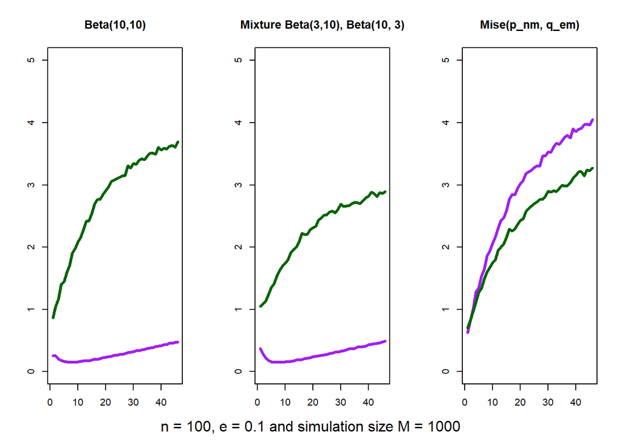

```r
par(mfrow=c(1,3))

# Plot both the mise between p_X and both q_e,m (darkgreen)
#and p_n,m (purple) for the beta(10,10)
matplot(Mise[2,], type = 'l', lwd=3, ylim= c(0,5),
        main='Beta(10,10)', col= 'purple', ylab = '')
matplot(Mise[3,], type = 'l', lwd=3, add=T, col='darkgreen')

# Plot both the mise between p_X and both q_e,m (darkgreen)
# and p_n,m (purple) for the mixture distribution
matplot(Mise[5,], type = 'l', lwd=3, ylim= c(0,5),
        main='Mixture Beta(3,10), Beta(10, 3)', col= 'purple',  ylab = '')
matplot(Mise[6,], type = 'l', lwd=3, add=T, col='darkgreen')

# Plot both the mise(q_e,m and p_n,m) for the beta(10,10) (purple)
# and the mixture (darkgreen)
matplot(Mise[1,], type = 'l', lwd=3, ylim= c(0,5),
        main='Mise(p_nm, q_em)', col= 'purple',  ylab = '')
matplot(Mise[4,], type = 'l', lwd=3, add=T, col='darkgreen')
mtext('n = 100, e = 0.1 and simulation size M = 1000', side=3, outer=TRUE, line=-37)
```

Now we repeat the same for all the combinations of n and e.

```r
e <- 0.01
n <- 100
Mise <- rep(NA, 6)
for(i in 5:50){
  Mise[i-4] = lapply(i, function(x) sim(x, n=n, e=e, M=M))
}
Mise <- matrix(unlist(Mise), nrow= 6, byrow = F)
```

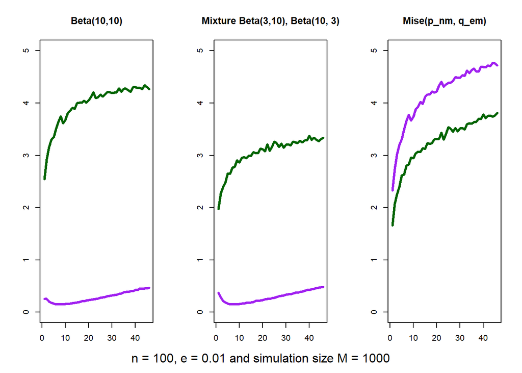

```r
par(mfrow=c(1,3))
matplot(Mise[2,], type = 'l', lwd=3, ylim= c(0,5),
        main='Beta(10,10)', col= 'purple', ylab = '')
matplot(Mise[3,], type = 'l', lwd=3, add=T, col='darkgreen')

matplot(Mise[5,], type = 'l', lwd=3, ylim= c(0,5),
        main='Mixture Beta(3,10), Beta(10, 3)', col= 'purple',  ylab = '')
matplot(Mise[6,], type = 'l', lwd=3, add=T, col='darkgreen')

matplot(Mise[1,], type = 'l', lwd=3, ylim= c(0,5),
        main='Mise(p_nm, q_em)', col= 'purple',  ylab = '')
matplot(Mise[4,], type = 'l', lwd=3, add=T, col='darkgreen')
mtext('n = 100, e = 0.01 and simulation size M = 1000', side=3, outer=TRUE, line=-37)
```

```r
e <- 0.1
n <- 1000
Mise <- rep(NA, 6)
for(i in 5:50){
  Mise[i-4] = lapply(i, function(x) sim(x, n=n, e=e, M=M))
}
Mise <- matrix(unlist(Mise), nrow= 6, byrow = F)
```

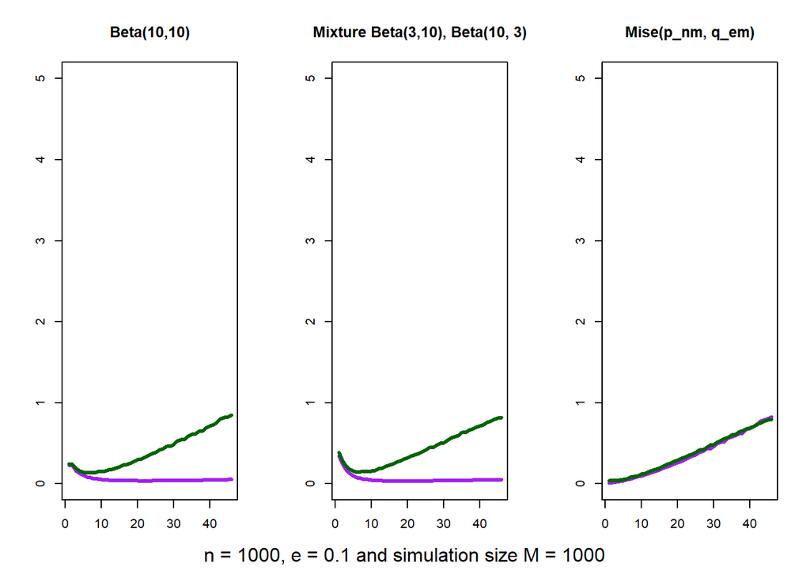

```r
par(mfrow=c(1,3))
matplot(Mise[2,], type = 'l', lwd=3, ylim= c(0,5),
        main='Beta(10,10)', col= 'purple', ylab = '')
matplot(Mise[3,], type = 'l', lwd=3, add=T, col='darkgreen')

matplot(Mise[5,], type = 'l', lwd=3, ylim= c(0,5),
        main='Mixture Beta(3,10), Beta(10, 3)', col= 'purple',  ylab = '')
matplot(Mise[6,], type = 'l', lwd=3, add=T, col='darkgreen')

matplot(Mise[1,], type = 'l', lwd=3, ylim= c(0,5),
        main='Mise(p_nm, q_em)', col= 'purple',  ylab = '')
matplot(Mise[4,], type = 'l', lwd=3, add=T, col='darkgreen')
mtext('n = 1000, e = 0.1 and simulation size M = 1000', side=3, outer=TRUE, line=-37)
```

```r
e <- 0.01
n <- 1000
Mise <- rep(NA, 6)
for(i in 5:50){
  Mise[i-4] = lapply(i, function(x) sim(x, n=n, e=e, M=M))
}
Mise <- matrix(unlist(Mise), nrow= 6, byrow = F)
```

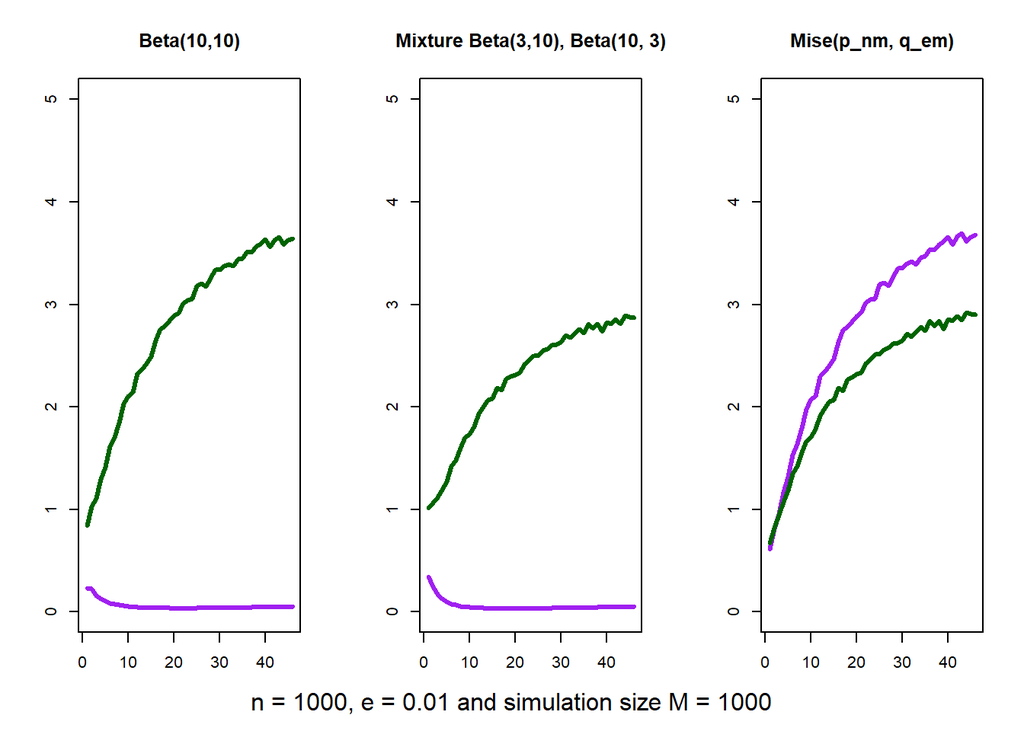

```r
par(mfrow=c(1,3))
matplot(Mise[2,], type = 'l', lwd=3, ylim= c(0,5),
        main='Beta(10,10)', col= 'purple', ylab = '')
matplot(Mise[3,], type = 'l', lwd=3, add=T, col='darkgreen')

matplot(Mise[5,], type = 'l', lwd=3, ylim= c(0,5),
        main='Mixture Beta(3,10), Beta(10, 3)', col= 'purple',  ylab = '')
matplot(Mise[6,], type = 'l', lwd=3, add=T, col='darkgreen')

matplot(Mise[1,], type = 'l', lwd=3, ylim= c(0,5),
        main='Mise(p_nm, q_em)', col= 'purple',  ylab = '')
matplot(Mise[4,], type = 'l', lwd=3, add=T, col='darkgreen')
mtext('n = 1000, e = 0.01 and simulation size M = 1000', side=3, outer=TRUE, line=-37)
```

By looking at the plots we can notice:. That increasing the number bins we have more information loss.. A trend of the perturbed histogram of the mixture model to be closer to the True density distribution, this can be also noticed in the case of the MISE(p_n,m , q_e,m). So being the distance less, in the case of mixture model, we can assume that less informations get lost in this case.

# Ex 2.3

For our sample we asked people how many minutes the spend on social networks daily. We ended up with a data collection of 104 responses.

```r
# Load the data
data <- read.csv("C:\\Users\\user\\Documents\\MAGISTRALE\\SDS\\Homeworks\\HW1\\SDS1.csv")
# Save the data in a matrix
data <- matrix(unlist(data), nrow= 1, byrow = F)
# The max of the data
max <- max(data)
# Normalize the data
data <- data/max(data)
```

The main function: (Repeat the same steps as the perturbed histogram in 2.1/2.2 but on our dataset.)

```r
Sim <- function(m, k, e){
  # Some initializations
  n <- length(data)
  # Number of bins
  D <- rep(0,m)
  n_hat <- rep(0, m+2)
  q <- rep(0, m+2)

  # Count how many elements are in each bin
  n_hat <- data.frame(table(cut(data, breaks = seq(min(data), max(data),
                          length.out = m+1),include.lowest = T)))[,2]

  # To compute the perturbed histogram
  v = rlaplace(m, 0, sqrt(8/(e^2)))

  for (t in 1:m){
    # Compute D_j_tilde
    D[t] = max(n_hat[t]+v[t],0)
  }
  for(t in 2:m+1){
    # Compute q_j_hat
    q[t] <- D[t]/sum(D)
  }

  # define the stepfunction for the histogram, with the extremes of the bins:
  x <- seq(min(data), max(data), length.out = m+1)
  q_fun <- stepfun(x,q*m)
  curve(q_fun(x), 0, 1, xlim = c(0,1), main='Histogram q_m,e', ylab = '')

  # Get a sample using the privatized histogram as distribution
  my_vec <- runif(1000000)
  # Get a sample of size k
  samp_Z <- sample(my_vec, size = k, replace = T, prob = q_fun(my_vec))

  return(samp_Z)
}
```

```r
k <- 25
m <- 20
e <- 0.01

# Get a sample of size k from the simulation function
samp_Z <- Sim(m, k, e)
```

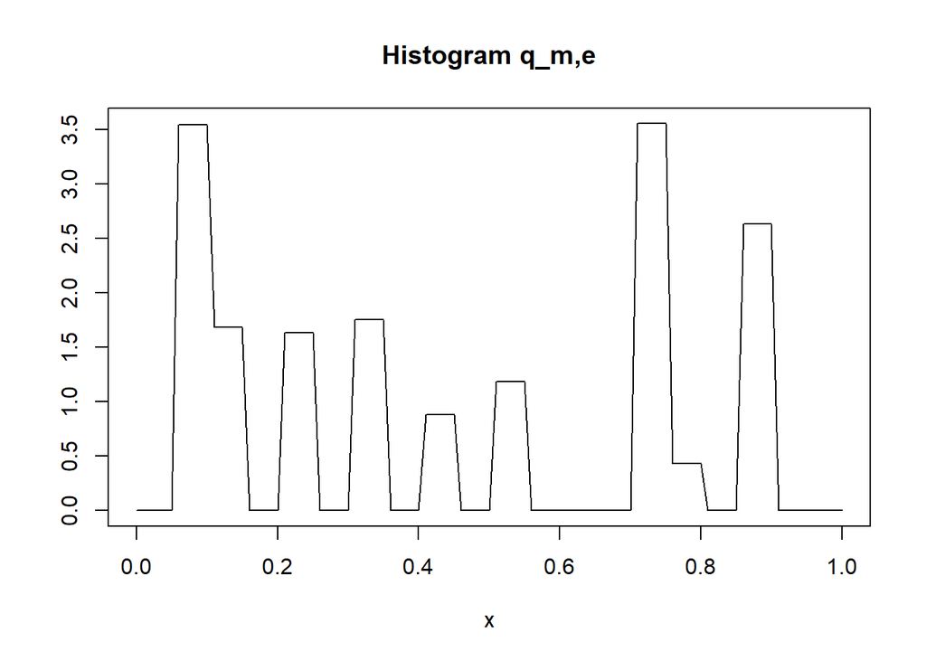

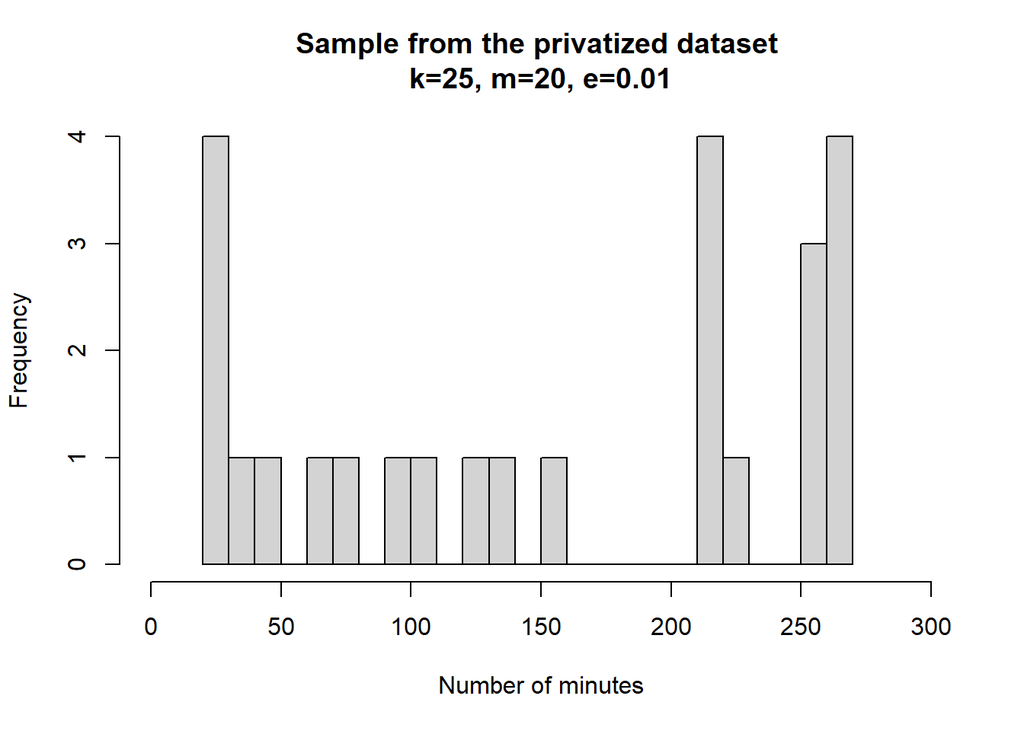

```r
# Go back to the original scale
samp_Z <- samp_Z*max
# Show the sample
hist(samp_Z, breaks = m, xlim = c(0,max),
     main = 'Sample from the privatized dataset \nk=25, m=20, e=0.01',
     xlab = 'Number of minutes')
```

```r
cat('And we have that the mean and the standard deviation before the privatization:\n'
    , mean(data*max), sd(data*max), '\nAfter:\n',mean(samp_Z), sd(samp_Z))
```

```
## And we have that the mean and the standard deviation before the privatization:
##  92.38462 67.02677
## After:
##  153.6675 93.62041
```

```r
k <- 50
m <- 20
e <- 0.01

# Get a sample of size k from the simulation function
samp_Z <- Sim(m, k, e)
```

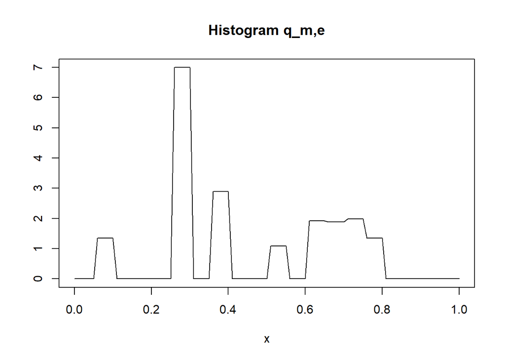

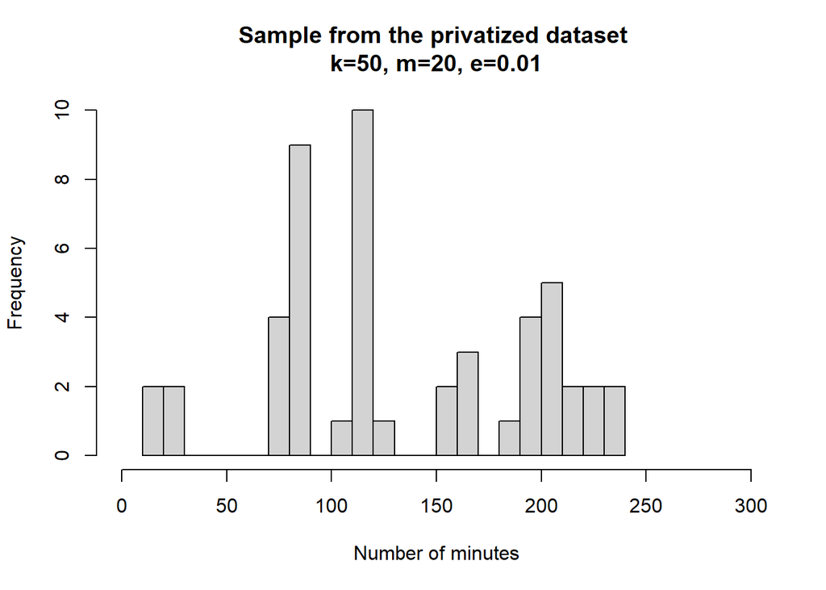

```r
# Go back to the original scale
samp_Z <- samp_Z*max
# Show the sample
hist(samp_Z, breaks = m, xlim = c(0,max),
     main = 'Sample from the privatized dataset \nk=50, m=20, e=0.01',
     xlab = 'Number of minutes')
```

```r
cat('And we have that the mean and the standard deviation before the privatization was:\n'
    , mean(data*max), sd(data*max),
    '\nAfter:\n',mean(samp_Z), sd(samp_Z))
```

```
## And we have that the mean and the standard deviation before the privatization was:
##  92.38462 67.02677
## After:
##  134.1315 61.88538
```

```r
k <- 75
m <- 20
e <- 0.01

# Get a sample of size k from the simulation function
samp_Z <- Sim(m, k, e)
```

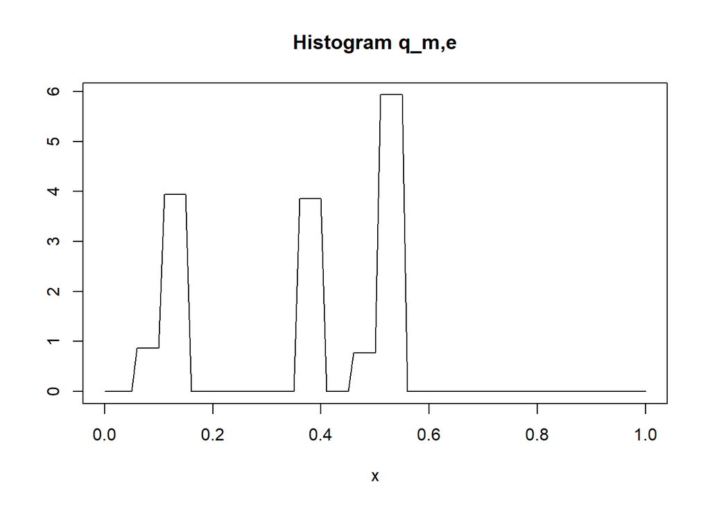

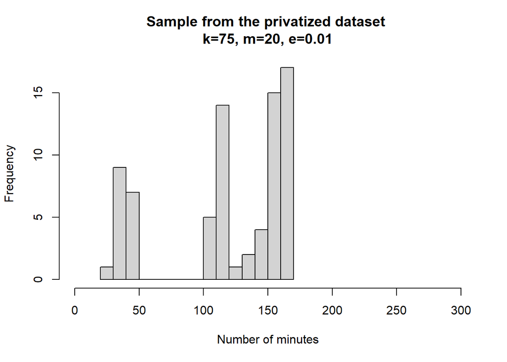

```r
# Go back to the original scale
samp_Z <- samp_Z*max
# Show the sample
hist(samp_Z, breaks = m, xlim = c(0,max),
     main = 'Sample from the privatized dataset \nk=75, m=20, e=0.01',
     xlab = 'Number of minutes')
```

```r
cat('And we have that the mean and the standard deviation before the privatization:\n'
    , mean(data*max), sd(data*max),
    '\nAfter:\n', mean(samp_Z), sd(samp_Z))
```

```
## And we have that the mean and the standard deviation before the privatization:
##  92.38462 67.02677
## After:
##  117.9795 47.92235
```

```r
k <- 100
m <- 20
e <- 0.01

# Get a sample of size k from the simulation function
samp_Z <- Sim(m, k, e)
```

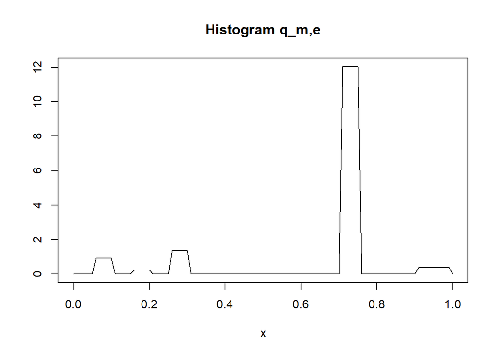

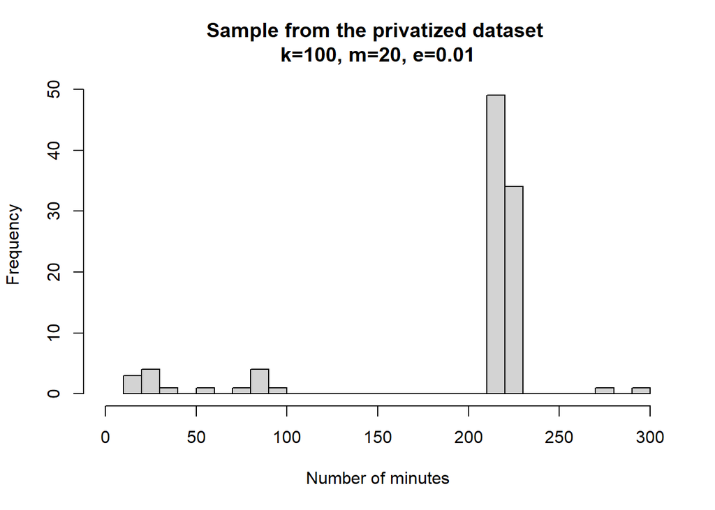

```r
# Go back to the original scale
samp_Z <- samp_Z*max
# Show the sample
hist(samp_Z, breaks = m, xlim = c(0,max),
     main = 'Sample from the privatized dataset \nk=100, m=20, e=0.01',
     xlab = 'Number of minutes')
```

```r
cat('And we have that the mean and the standard deviation before the privatization:\n'
    , mean(data*max), sd(data*max),
    '\nAfter:\n',mean(samp_Z), sd(samp_Z))
```

```
## And we have that the mean and the standard deviation before the privatization:
##  92.38462 67.02677
## After:
##  194.0433 63.161
```

As for our decisions we chose: - e = 0.01, because from the previous point we saw that it ensure a better privatization. - m = 20, because we found it to be the best number or bins to rapresent our data. And because we noticed before that there is more information loss with increasing the number of bins. - k in {25, 50, 75, 100}, to show how the results change with it.

# Ex 2.4 (bonus)

Initialization

```r
n <- 1000
M <- 10000
m <- 30
e <- 0.1
p_j1 = rep(0,m+2)
q_j1 = rep(0,m+2)
p_j2 = rep(0,m+2)
q_j2 = rep(0,m+2)
D_j1 = rep(0,m)
D_j2 = rep(0,m)
MAX <- rep(NA, M)
```

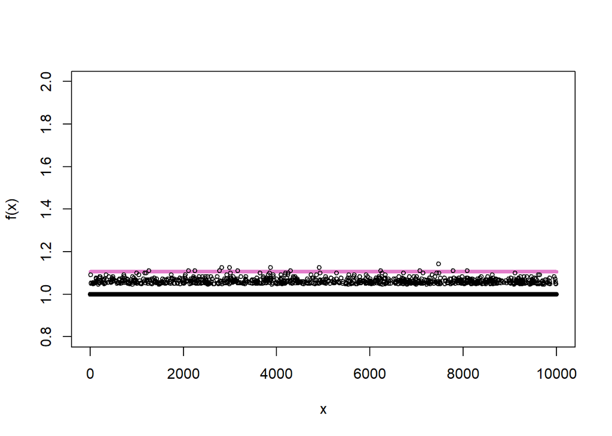

```r
for(k in (1:M)){

  # n-1 elements that are going to be the same for both datasets
  X = rbeta(n-1, 10, 10)

  # Add the different value in the datasets
  X1 = c(X, rbeta(1, 10, 10))
  X2 = c(X, rbeta(1, 10, 10))

  # Follow the same steps as the previous point to make the privitized histograms

  for(t in 2:m+1){
    p_j1[t] = (sum(X1>((t-2)/m) & X1<=((t-1)/m))/n)
    p_j2[t] = (sum(X2>((t-2)/m) & X2<=((t-1)/m))/n)
  }

  # integral q_e,m
  v = rlaplace(m, 0, sqrt(8/(e^2)))

  for (t in 1:m){
    D_j1[t] = max((p_j1[t+1]*n)+v[t],0)
    D_j2[t] = max((p_j2[t+1]*n)+v[t],0)
  }

  D1 = sum(D_j1)
  D2 = sum(D_j2)

  for (t in 2:m+1){
    if(D1){
      q_j1[t] = m*D_j1[t-1]/D1
    }
    if(D2){
      q_j2[t] = m*D_j2[t-1]/D2
    }
  }

  # Find the CDF for the distributions
  fun_q1 <- ecdf(q_j1)
  fun_q2 <- ecdf(q_j2)

  # Find the points for the evaluation of the CDFs
  x <- seq(0, 1, length.out = m+1)

  # find the max value of the division
  max = 0
  for(i in (1:m)){
    a = (x[i+1]+x[i])/2
    if(fun_q2(a)!=0){
      if((fun_q1(a)/fun_q2(a)) > max){
        max = fun_q1(a)/fun_q2(a)
      }
    }else if(fun_q1(a) & 1 > max){
      max = 1
    }
  }
  # Save the max
  MAX[k] <- max
}

# Plot the line exp(e)
f<-function(x){
  return(rep(exp(e),length(x)))
}
curve(f(x), seq(0,M, by=0.001) , lwd = 4, ylim=c(0.8,2),
      col = rgb(.85, .32, .73,.75), M)

# Add the MAX to the plot
points(1:M, MAX[1:M], pch = 1,
       col = "black", bg = "yellow", cex = .7)
```

```r
cat('As we can see e-private property seems to be verified.\nWe have that, out of the', M, 'experitments, only', sum(MAX>exp(e))/M*100,'% of the values are over exp(e).')
```

```
## As we can see e-private property seems to be verified.
## We have that, out of the 10000 experitments, only 0.15 % of the values are over exp(e).
```